# Public health and economic consequences of storms and other severe weather events

## Synopsis

The analysis below examines storms and other severe weather event data from the U.S. National Oceanic and Atmospheric Administration’s (NOAA) storm database. The data cover the time period 1950-November 2011, with 902,297 events in total. Statistics are reported on the event types that caused the most damage across the United States in terms of public health and economic consequences. Public health consequences are measured as the total fatalities, injuries or casualties for each event type. Economic consequences are measured by total property damage, crop damage and combined damage in dollars for each event type. The event types in the top 1% are reported in each case. For casualties and combined damage, the most harmful event type was tornado.

## Data Processing

### Download the data

Unzip the data if required, then read into memory as data1.

```r
library(R.utils)
url <- "https://d396qusza40orc.cloudfront.net/repdata%2Fdata%2FStormData.csv.bz2"
csvFile <- "StormData.csv"
zipFile <- paste0(csvFile, ".bz2")
if (!file.exists(zipFile)) {
        download.file(url, zipFile, method = "curl")
}
if (!file.exists(csvFile)) {
        bunzip2(zipFile, csvFile, overwrite = TRUE)
}
data1 <- read.csv(csvFile)
```

### Process the raw data

- Create a new data frame data2 with the variables EVTYPE, FATALITIES, INJURIES, PROPDMG, and CROPDMG.
- Trim the EVTYPE variable.
- Create variable casualties which represents combined fatalities and injuries.
- Create variable combinedDamage which represents combined property damage and crop damage.

```r
library(gdata)
data2 <- data1[, c(8, 23, 24, 25, 27)]
trim(data2$EVTYPE, recode.factor = TRUE)
data2$casualties <- data2$FATALITIES + data2$INJURIES
data2$combinedDamage <- data2$PROPDMG + data2$CROPDMG
```

### Summary of Data

Report the dimensions of the raw data, and the dimensions, incomplete cases, and first few rows of data2.

```r
dim(data1)
```

```
## [1] 902297     37
```

```r
dim(data2)
```

```
## [1] 902297      7
```

```r
sum(complete.cases(data2))
```

```
## [1] 902297
```

```r
head(data2)
```

```
##    EVTYPE FATALITIES INJURIES PROPDMG CROPDMG casualties combinedDamage
## 1 TORNADO          0       15    25.0       0         15           25.0
## 2 TORNADO          0        0     2.5       0          0            2.5
## 3 TORNADO          0        2    25.0       0          2           25.0
## 4 TORNADO          0        2     2.5       0          2            2.5
## 5 TORNADO          0        2     2.5       0          2            2.5
## 6 TORNADO          0        6     2.5       0          6            2.5
```

Report descriptive statistics for all variables of interest.

```r
summary(data2)
```

```
##                EVTYPE         FATALITIES     INJURIES         PROPDMG
##  HAIL             :288661   Min.   :  0   Min.   :   0.0   Min.   :   0
##  TSTM WIND        :219940   1st Qu.:  0   1st Qu.:   0.0   1st Qu.:   0
##  THUNDERSTORM WIND: 82563   Median :  0   Median :   0.0   Median :   0
##  TORNADO          : 60652   Mean   :  0   Mean   :   0.2   Mean   :  12
##  FLASH FLOOD      : 54277   3rd Qu.:  0   3rd Qu.:   0.0   3rd Qu.:   0
##  FLOOD            : 25326   Max.   :583   Max.   :1700.0   Max.   :5000
##  (Other)          :170878
##     CROPDMG        casualties     combinedDamage
##  Min.   :  0.0   Min.   :   0.0   Min.   :   0
##  1st Qu.:  0.0   1st Qu.:   0.0   1st Qu.:   0
##  Median :  0.0   Median :   0.0   Median :   0
##  Mean   :  1.5   Mean   :   0.2   Mean   :  14
##  3rd Qu.:  0.0   3rd Qu.:   0.0   3rd Qu.:   1
##  Max.   :990.0   Max.   :1742.0   Max.   :5000
##
```

## Results

Create a table showing the sums of casualties and combined damage by event type.

```r
library(plyr)
library(reshape2)
data3 <- melt(data2, id = "EVTYPE")
data4 <- ddply(data3, .(EVTYPE, variable), summarise,
               sum = sum(value, na.rm = TRUE))
data5 <- dcast(data4, EVTYPE ~ variable, sum)
head(data5)
```

```
##                  EVTYPE FATALITIES INJURIES PROPDMG CROPDMG casualties
## 1    HIGH SURF ADVISORY          0        0     200       0          0
## 2         COASTAL FLOOD          0        0       0       0          0
## 3           FLASH FLOOD          0        0      50       0          0
## 4             LIGHTNING          0        0       0       0          0
## 5             TSTM WIND          0        0     108       0          0
## 6       TSTM WIND (G45)          0        0       8       0          0
##   combinedDamage
## 1            200
## 2              0
## 3             50
## 4              0
## 5            108
## 6              8
```

### Public health consequences

Report event types in the top 1% for public health consequences for fatalities, injuries and casualties. Plot the top 1% of event types for casualties.

```r
library(ggplot2)
library(scales)
data6 <- arrange(data5[data5$FATALITIES > quantile(data5$FATALITIES, 0.99), c(1, 2)],
        desc(FATALITIES))
data7 <- arrange(data5[data5$INJURIES > quantile(data5$INJURIES, 0.99), c(1, 3)],
        desc(INJURIES))
data8 <- arrange(data5[data5$casualties > quantile(data5$casualties, 0.99), c(1, 6)],
        desc(casualties))
data8$EVTYPE <- factor(data8$EVTYPE, levels = data8$EVTYPE, ordered = TRUE)
bar1 <- ggplot() + geom_bar(aes(x = EVTYPE, y = casualties), data8, stat = "identity") +
        ggtitle("Casualties Top 1% Event Types") +
        xlab("Event Type") + ylab("Total Casualties") +
        theme(axis.text.x = element_text(angle = 90)) +
        scale_y_continuous(labels = comma)
data6
```

```
##            EVTYPE FATALITIES
## 1         TORNADO       5633
## 2  EXCESSIVE HEAT       1903
## 3     FLASH FLOOD        978
## 4            HEAT        937
## 5       LIGHTNING        816
## 6       TSTM WIND        504
## 7           FLOOD        470
## 8     RIP CURRENT        368
## 9       HIGH WIND        248
## 10      AVALANCHE        224
```

```r
data7
```

```
##               EVTYPE INJURIES
## 1            TORNADO    91346
## 2          TSTM WIND     6957
## 3              FLOOD     6789
## 4     EXCESSIVE HEAT     6525
## 5          LIGHTNING     5230
## 6               HEAT     2100
## 7          ICE STORM     1975
## 8        FLASH FLOOD     1777
## 9  THUNDERSTORM WIND     1488
## 10              HAIL     1361
```

```r
data8
```

```
##               EVTYPE casualties
## 1            TORNADO      96979
## 2     EXCESSIVE HEAT       8428
## 3          TSTM WIND       7461
## 4              FLOOD       7259
## 5          LIGHTNING       6046
## 6               HEAT       3037
## 7        FLASH FLOOD       2755
## 8          ICE STORM       2064
## 9  THUNDERSTORM WIND       1621
## 10      WINTER STORM       1527
```

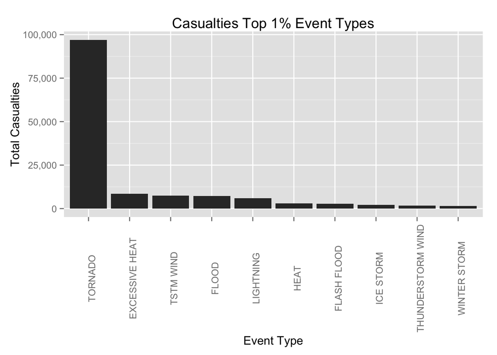

```r
bar1
```

### Economic consequences

Report event types in the top 1% for economic consequences for property damage, crop damage and combined damage. Plot the top 1% of event types for combined damage.

```r
library(ggplot2)
library(scales)
data9 <- arrange(data5[data5$PROPDMG > quantile(data5$PROPDMG, 0.99), c(1, 4)],
        desc(PROPDMG))
data10 <- arrange(data5[data5$CROPDMG > quantile(data5$CROPDMG, 0.99), c(1, 5)],
        desc(CROPDMG))
data11 <- arrange(data5[data5$combinedDamage > quantile(data5$combinedDamage, 0.99), c(1, 7)],
        desc(combinedDamage))
data11$EVTYPE <- factor(data11$EVTYPE, levels = data11$EVTYPE, ordered = TRUE)
bar2 <- ggplot() + geom_bar(aes(x = EVTYPE, y = combinedDamage), data11, stat = "identity") +
        ggtitle("Combined Damage Top 1% Event Types") +
        xlab("Event Type") + ylab("Total Combined Damage") +
        theme(axis.text.x = element_text(angle = 90)) +
        scale_y_continuous(labels = dollar)
data9
```

```
##                EVTYPE PROPDMG
## 1             TORNADO 3212258
## 2         FLASH FLOOD 1420125
## 3           TSTM WIND 1335966
## 4               FLOOD  899938
## 5   THUNDERSTORM WIND  876844
## 6                HAIL  688693
## 7           LIGHTNING  603352
## 8  THUNDERSTORM WINDS  446293
## 9           HIGH WIND  324732
## 10       WINTER STORM  132721
```

```r
data10
```

```
##                EVTYPE CROPDMG
## 1                HAIL  579596
## 2         FLASH FLOOD  179200
## 3               FLOOD  168038
## 4           TSTM WIND  109203
## 5             TORNADO  100019
## 6   THUNDERSTORM WIND   66791
## 7             DROUGHT   33899
## 8  THUNDERSTORM WINDS   18685
## 9           HIGH WIND   17283
## 10         HEAVY RAIN   11123
```

```r
data11
```

```
##                EVTYPE combinedDamage
## 1             TORNADO        3312277
## 2         FLASH FLOOD        1599325
## 3           TSTM WIND        1445168
## 4                HAIL        1268290
## 5               FLOOD        1067976
## 6   THUNDERSTORM WIND         943636
## 7           LIGHTNING         606932
## 8  THUNDERSTORM WINDS         464978
## 9           HIGH WIND         342015
## 10       WINTER STORM         134700
```

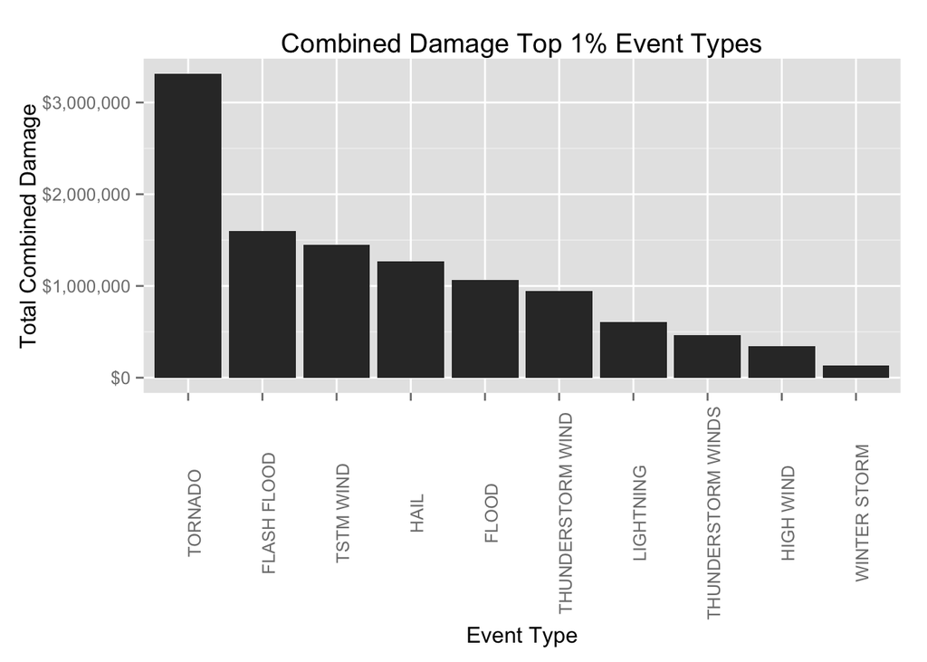

```r
bar2
```